# codigo comparativo y regionalizacion

2026-07-23

# 1. Preparación de la base

## Librerías

```r
library(readxl)
library(dplyr)
library(tidyr)
```

```r
library(ggplot2)
library(scales)
library(sf)
library(rnaturalearth)
```

## Carpeta de gráficas

```r
carpeta_graficas <- "Figuras_Revista"

dir.create(
  carpeta_graficas,
  recursive = TRUE,
  showWarnings = FALSE
)
```

## Base

```r
# Base
archivo_base <- "04_base_comparativa_estados.xlsx"

base_comparativa_estados <- read_excel(archivo_base, sheet = "Base")
```

## Funcion para guardar gráficas

```r
# Crear una función para guardar gráficas en PNG

guardar_grafica_png <- function(
    grafica,
    nombre_archivo,
    ancho = 10,
    alto = 7,
    resolucion = 600
) {

  ggsave(
    filename = file.path(
      carpeta_graficas,
      paste0(
        nombre_archivo,
        ".png"
      )
    ),
    plot = grafica,
    width = ancho,
    height = alto,
    units = "in",
    dpi = resolucion,
    bg = "white"
  )
}
```

## Tema general de las gráficas

```r
# Crear el tema general para las gráficas del artículo

tema_articulo <- theme_minimal(base_size = 13) +
  theme(
    plot.title = element_blank(),

    axis.title = element_text(
      size = 12,
      color = "gray20"
    ),

    axis.text = element_text(
      size = 11,
      color = "gray25"
    ),

    panel.grid.minor = element_blank(),

    panel.grid.major.x = element_blank(),

    panel.grid.major.y = element_line(
      color = "gray90",
      linewidth = 0.25
    ),

    legend.position = "bottom",

    legend.title = element_blank(),

    legend.text = element_text(
      size = 11
    ),

    legend.justification = "center",

    strip.text = element_text(
      size = 11,
      color = "gray20",
      face = "bold"
    ),

    plot.caption = element_text(
      size = 10,
      color = "gray35",
      hjust = 0
    ),

    plot.margin = margin(
      t = 15,
      r = 15,
      b = 15,
      l = 15
    )
  )
```

# 2. Construcción de las participaciones sectoriales

## Cálculo de las participaciones

```r
# Crear la base estatal con niveles y participaciones sectoriales

base_estatal <- base_comparativa_estados %>%
  mutate(
    estado = trimws(estado),
    año = as.integer(año),
    primarias_pct = primarias_nivel / pib_nivel,
    secundarias_pct = secundarias_nivel / pib_nivel,
    terciarias_pct = terciarias_nivel / pib_nivel
  ) %>%
  arrange(
    estado,
    año
  )
```

# 3. Análisis descriptivo estatal de la terciarización

## Cambio de la participación terciaria por entidad

```r
# Calcular el cambio de la participación terciaria entre 1980 y 2024

cambio_estatal <- base_estatal %>%
  filter(
    año %in% c(1980, 2024)
  ) %>%
  select(
    estado,
    año,
    terciarias_pct
  ) %>%
  pivot_wider(
    names_from = año,
    values_from = terciarias_pct,
    names_prefix = "terciarias_"
  ) %>%
  mutate(
    cambio_pp = (
      terciarias_2024 -
        terciarias_1980
    ) * 100
  )
```

## Referencias del cambio entre entidades

```r
# Calcular el cambio promedio y mediano de las entidades

referencias_cambio_estatal <- cambio_estatal %>%
  summarise(
    cambio_promedio_pp = mean(
      cambio_pp
    ),

    cambio_mediano_pp = median(
      cambio_pp
    ),

    entidades_con_aumento = sum(
      cambio_pp > 0
    ),

    entidades_con_disminucion = sum(
      cambio_pp < 0
    ),

    porcentaje_con_aumento = mean(
      cambio_pp > 0
    ) * 100
  )

cambio_promedio_pp <- referencias_cambio_estatal$cambio_promedio_pp

cambio_mediano_pp <- referencias_cambio_estatal$cambio_mediano_pp

referencias_cambio_estatal
```

```
## # A tibble: 1 × 5
##   cambio_promedio_pp cambio_mediano_pp entidades_con_aumento
##                <dbl>             <dbl>                 <int>
## 1               5.90              6.49                    26
## # ℹ 2 more variables: entidades_con_disminucion <int>,
## #   porcentaje_con_aumento <dbl>
```

## Comparación con el cambio promedio

```r
# Comparar el cambio de cada entidad con el promedio estatal

cambio_estatal <- cambio_estatal %>%
  mutate(
    diferencia_promedio_pp = cambio_pp -
      cambio_promedio_pp,

    comparacion_promedio = if_else(
      cambio_pp >= cambio_promedio_pp,
      "Por encima del promedio",
      "Por debajo del promedio"
    )
  ) %>%
  arrange(
    desc(cambio_pp)
  )
```

## Resultado de Nuevo León

```r
# Obtener el resultado correspondiente a Nuevo León

resultado_nuevo_leon_estatal <- cambio_estatal %>%
  filter(
    estado == "Nuevo León"
  ) %>%
  transmute(
    Estado = estado,

    `Participación terciaria 1980 (%)` = round(
      terciarias_1980 * 100,
      2
    ),

    `Participación terciaria 2024 (%)` = round(
      terciarias_2024 * 100,
      2
    ),

    `Cambio 1980-2024 (p.p.)` = round(
      cambio_pp,
      2
    ),

    `Diferencia frente al promedio (p.p.)` = round(
      diferencia_promedio_pp,
      2
    ),

    `Comparación con el promedio` = comparacion_promedio
  )

resultado_nuevo_leon_estatal
```

```
## # A tibble: 1 × 6
##   Estado    Participación tercia…¹ Participación tercia…² Cambio 1980-2024 (p.…³
##   <chr>                      <dbl>                  <dbl>                  <dbl>
## 1 Nuevo Le…                   45.6                   53.8                   8.13
## # ℹ abbreviated names: ¹`Participación terciaria 1980 (%)`,
## #   ²`Participación terciaria 2024 (%)`, ³`Cambio 1980-2024 (p.p.)`
## # ℹ 2 more variables: `Diferencia frente al promedio (p.p.)` <dbl>,
## #   `Comparación con el promedio` <chr>
```

## Posición de Nuevo León y resumen del cambio estatal

```r
# Calcular las posiciones estatales en 1980, 2024 y por cambio acumulado

posiciones_estatales <- cambio_estatal %>%
  mutate(
    posicion_1980 = min_rank(
      desc(terciarias_1980)
    ),

    posicion_2024 = min_rank(
      desc(terciarias_2024)
    ),

    posicion_cambio = min_rank(
      desc(cambio_pp)
    )
  )
```

La posición 1 representa:

- la mayor participación terciaria en 1980;
- la mayor participación terciaria en 2024;
- el mayor aumento en puntos porcentuales entre 1980 y 2024.

```r
# Obtener las posiciones correspondientes a Nuevo León

posicion_nuevo_leon <- posiciones_estatales %>%
  filter(
    estado == "Nuevo León"
  ) %>%
  summarise(
    posicion_1980 = posicion_1980,
    posicion_2024 = posicion_2024,
    posicion_cambio = posicion_cambio
  )
```

```r
# Construir la tabla resumen del análisis estatal

tabla_resumen_estatal <- tibble::tibble(
  Indicador = c(
    "Entidades con aumento",
    "Entidades con disminución",
    "Entidades por encima del cambio promedio",
    "Entidades por debajo del cambio promedio",
    "Cambio promedio de las entidades",
    "Cambio mediano de las entidades",
    "Posición de Nuevo León por participación en 1980",
    "Posición de Nuevo León por participación en 2024",
    "Posición de Nuevo León por cambio en puntos porcentuales"
  ),

  Resultado = c(
    sum(cambio_estatal$cambio_pp > 0),
    sum(cambio_estatal$cambio_pp < 0),
    sum(cambio_estatal$cambio_pp > cambio_promedio_pp),
    sum(cambio_estatal$cambio_pp < cambio_promedio_pp),
    paste0(
      round(cambio_promedio_pp, 2),
      " p.p."
    ),
    paste0(
      round(cambio_mediano_pp, 2),
      " p.p."
    ),
    paste0(
      posicion_nuevo_leon$posicion_1980,
      " de 32"
    ),
    paste0(
      posicion_nuevo_leon$posicion_2024,
      " de 32"
    ),
    paste0(
      posicion_nuevo_leon$posicion_cambio,
      " de 32"
    )
  )
)

tabla_resumen_estatal
```

```
## # A tibble: 9 × 2
##   Indicador                                                Resultado
##   <chr>                                                    <chr>
## 1 Entidades con aumento                                    26
## 2 Entidades con disminución                                6
## 3 Entidades por encima del cambio promedio                 18
## 4 Entidades por debajo del cambio promedio                 14
## 5 Cambio promedio de las entidades                         5.9 p.p.
## 6 Cambio mediano de las entidades                          6.49 p.p.
## 7 Posición de Nuevo León por participación en 1980         22 de 32
## 8 Posición de Nuevo León por participación en 2024         19 de 32
## 9 Posición de Nuevo León por cambio en puntos porcentuales 12 de 32
```

## Gráfica del cambio por entidad

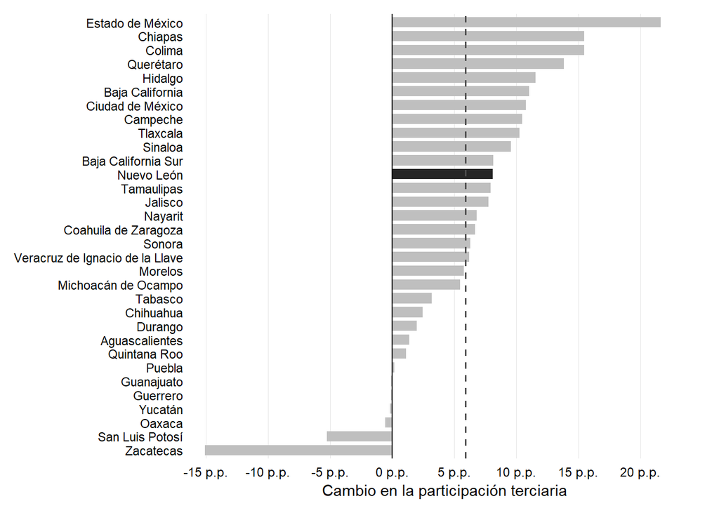

```r
# Ordenar las entidades según el cambio en la participación terciaria

orden_estados <- cambio_estatal %>%
  arrange(
    cambio_pp
  ) %>%
  pull(
    estado
  )

datos_grafica_cambio_estatal <- cambio_estatal %>%
  mutate(
    estado = factor(
      estado,
      levels = orden_estados
    )
  )

grafica_cambio_estatal <- ggplot(
  datos_grafica_cambio_estatal,
  aes(
    x = estado,
    y = cambio_pp,
    fill = estado == "Nuevo León"
  )
) +

  # Barras
  geom_col(
    width = 0.75
  ) +

  # Línea de referencia del promedio estatal
  geom_hline(
    yintercept = cambio_promedio_pp,
    color = "gray30",
    linewidth = 0.6,
    linetype = "dashed"
  ) +

  # Línea del valor cero
  geom_hline(
    yintercept = 0,
    color = "black",
    linewidth = 0.4
  ) +

  # Destacar Nuevo León
  scale_fill_manual(
    values = c(
      "TRUE" = "gray15",
      "FALSE" = "gray75"
    ),
    guide = "none"
  ) +

  # Barras horizontales
  coord_flip() +

  # Corregir nombre del Estado de México
  scale_x_discrete(
    labels = c(
      "México" = "Estado de México"
    )
  ) +

  # Eje de cambios
  scale_y_continuous(
    labels = label_number(
      accuracy = 1,
      suffix = " p.p."
    ),
    breaks = pretty_breaks(n = 7),
    expand = expansion(
      mult = c(0.03, 0.08)
    )
  ) +

  labs(
    x = NULL,
    y = "Cambio en la participación terciaria"
  ) +

  tema_articulo +

  theme(
    legend.position = "none",

    axis.title.x = element_text(
      size = 11,
      color = "black"
    ),

    axis.text.x = element_text(
      size = 9,
      color = "black"
    ),

    axis.text.y = element_text(
      size = 8.5,
      color = "black"
    ),

    panel.grid.major.y = element_blank(),

    panel.grid.major.x = element_line(
      color = "gray90",
      linewidth = 0.25
    ),

    panel.grid.minor = element_blank(),

    plot.margin = margin(10, 15, 10, 10)
  )

# Mostrar gráfica
grafica_cambio_estatal
```

```r
# Exportar en TIFF a 300 DPI
ggsave(
  filename = "Figuras_Revista/Anexo_A_Cambio_terciario_32_entidades.tiff",
  plot = grafica_cambio_estatal,
  width = 17,
  height = 19,
  units = "cm",
  dpi = 300,
  compression = "lzw",
  bg = "white"
)
```

Entre 1980 y 2024, la participación del sector terciario aumentó en 26 de las 32 entidades federativas y disminuyó únicamente en 6, lo que muestra que la terciarización fue un proceso ampliamente extendido, aunque con intensidades muy distintas entre estados. El aumento promedio fue de 5.9 puntos porcentuales y la mediana de 6.49 puntos porcentuales; 18 entidades registraron variaciones superiores al promedio y 14 se ubicaron por debajo. Los puntos porcentuales (p.p.) expresan la diferencia directa entre dos porcentajes: por ejemplo, pasar de 50% a 58% representa un aumento de 8 p.p., no de 8%.

Nuevo León presentó un avance mayor que el promedio nacional de las entidades y ocupó la posición 12 de 32 por el incremento de su participación terciaria. Además, pasó del lugar 22 en 1980 al 19 en 2024, una mejora de tres posiciones. Esto indica que el sector terciario ganó relevancia en la estructura económica estatal, aunque el aumento fue menor que el observado en las entidades que encabezaron el proceso de terciarización.

# 4. Regionalización de las entidades federativas

```r
# Crear el catálogo regional de Banco de México

catalogo_regiones <- tibble::tribble(
  ~estado, ~region,
  "Baja California", "Norte",
  "Chihuahua", "Norte",
  "Coahuila de Zaragoza", "Norte",
  "Nuevo León", "Norte",
  "Sonora", "Norte",
  "Tamaulipas", "Norte",
  "Aguascalientes", "Centro norte",
  "Baja California Sur", "Centro norte",
  "Colima", "Centro norte",
  "Durango", "Centro norte",
  "Jalisco", "Centro norte",
  "Michoacán de Ocampo", "Centro norte",
  "Nayarit", "Centro norte",
  "San Luis Potosí", "Centro norte",
  "Sinaloa", "Centro norte",
  "Zacatecas", "Centro norte",
  "Ciudad de México", "Centro",
  "México", "Centro",
  "Guanajuato", "Centro",
  "Hidalgo", "Centro",
  "Morelos", "Centro",
  "Puebla", "Centro",
  "Querétaro", "Centro",
  "Tlaxcala", "Centro",
  "Campeche", "Sur",
  "Chiapas", "Sur",
  "Guerrero", "Sur",
  "Oaxaca", "Sur",
  "Quintana Roo", "Sur",
  "Tabasco", "Sur",
  "Veracruz de Ignacio de la Llave", "Sur",
  "Yucatán", "Sur"
)
```

```r
# Incorporar la región a la base estatal

base_estatal <- base_estatal %>%
  left_join(
    catalogo_regiones,
    by = "estado"
  ) %>%
  mutate(
    region = factor(
      region,
      levels = c(
        "Norte",
        "Centro norte",
        "Centro",
        "Sur"
      )
    )
  ) %>%
  arrange(
    region,
    estado,
    año
  )
```

## Indicadores regionales anuales

```r
# Calcular los indicadores anuales de terciarización por región

indicadores_regionales <- base_estatal %>%
  group_by(
    region,
    año
  ) %>%
  summarise(
    terciarias_regional = sum(
      terciarias_nivel
    ) / sum(
      pib_nivel
    ),

    terciarias_promedio = mean(
      terciarias_pct
    ),

    terciarias_mediana = median(
      terciarias_pct
    ),

    dispersion_estatal = sd(
      terciarias_pct
    ),

    .groups = "drop"
  )
```

## Cambio regional entre 1980 y 2024

```r
# Calcular el cambio de los indicadores regionales entre 1980 y 2024

cambio_regional <- indicadores_regionales %>%
  filter(
    año %in% c(1980, 2024)
  ) %>%
  select(
    region,
    año,
    terciarias_regional,
    terciarias_promedio,
    terciarias_mediana
  ) %>%
  pivot_wider(
    names_from = año,
    values_from = c(
      terciarias_regional,
      terciarias_promedio,
      terciarias_mediana
    ),
    names_glue = "{.value}_{año}"
  ) %>%
  mutate(
    cambio_regional_pp = (
      terciarias_regional_2024 -
        terciarias_regional_1980
    ) * 100,

    cambio_promedio_pp = (
      terciarias_promedio_2024 -
        terciarias_promedio_1980
    ) * 100,

    cambio_mediana_pp = (
      terciarias_mediana_2024 -
        terciarias_mediana_1980
    ) * 100
  )
```

## Entidades con aumento y disminución por región

```r
# Contar las entidades con aumento y disminución dentro de cada región

cambio_estatal_region <- cambio_estatal %>%
  left_join(
    catalogo_regiones,
    by = "estado"
  )

conteo_cambio_region <- cambio_estatal_region %>%
  group_by(region) %>%
  summarise(
    numero_entidades = n(),

    entidades_con_aumento = sum(
      cambio_pp > 0
    ),

    entidades_con_disminucion = sum(
      cambio_pp < 0
    ),

    .groups = "drop"
  )
```

## Tabla resumen regional

```r
# Construir la tabla resumen del cambio regional

tabla_resumen_regional <- cambio_regional %>%
  left_join(
    conteo_cambio_region,
    by = "region"
  ) %>%
  transmute(
    Región = as.character(region),

    `Participación regional 1980 (%)` = round(
      terciarias_regional_1980 * 100,
      2
    ),

    `Participación regional 2024 (%)` = round(
      terciarias_regional_2024 * 100,
      2
    ),

    `Cambio regional (p.p.)` = round(
      cambio_regional_pp,
      2
    ),

    `Cambio del promedio estatal (p.p.)` = round(
      cambio_promedio_pp,
      2
    ),

    `Cambio de la mediana estatal (p.p.)` = round(
      cambio_mediana_pp,
      2
    ),

    `Entidades con aumento` = entidades_con_aumento,

    `Entidades con disminución` = entidades_con_disminucion
  )

tabla_resumen_regional
```

```
## # A tibble: 4 × 8
##   Región    Participación region…¹ Participación region…² Cambio regional (p.p…³
##   <chr>                      <dbl>                  <dbl>                  <dbl>
## 1 Norte                       40.6                   48.4                   7.74
## 2 Centro n…                   55.0                   59.2                   4.27
## 3 Centro                      60.0                   69.6                   9.68
## 4 Sur                         45.4                   56.1                  10.7
## # ℹ abbreviated names: ¹`Participación regional 1980 (%)`,
## #   ²`Participación regional 2024 (%)`, ³`Cambio regional (p.p.)`
## # ℹ 4 more variables: `Cambio del promedio estatal (p.p.)` <dbl>,
## #   `Cambio de la mediana estatal (p.p.)` <dbl>, `Entidades con aumento` <int>,
## #   `Entidades con disminución` <int>
```

## Evolución de la participación terciaria regional

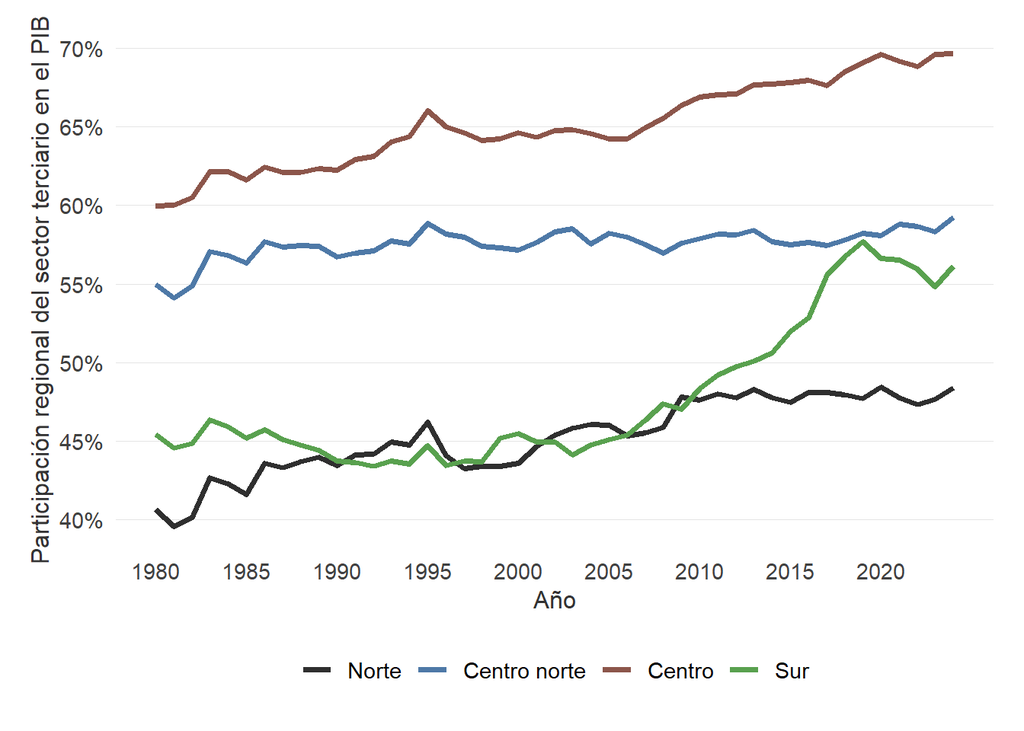

```r
# Definir los colores de las regiones

colores_regiones <- c(
  "Norte" = "#2F2F2F",
  "Centro norte" = "#4E79A7",
  "Centro" = "#8C564B",
  "Sur" = "#59A14F"
)

# Graficar la evolución de la participación terciaria regional

grafica_evolucion_regional <- ggplot(
  indicadores_regionales,
  aes(
    x = año,
    y = terciarias_regional,
    color = region
  )
) +

  geom_line(
    linewidth = 1.25
  ) +

  scale_color_manual(
    values = colores_regiones
  ) +

  scale_y_continuous(
    labels = percent_format(
      accuracy = 1
    ),
    breaks = pretty_breaks(
      n = 6
    )
  ) +

  scale_x_continuous(
    breaks = seq(
      1980,
      2024,
      5
    )
  ) +

  labs(
    x = "Año",
    y = "Participación regional del sector terciario en el PIB"
  ) +

  tema_articulo

grafica_evolucion_regional
```

```r
guardar_grafica_png(
  grafica = grafica_evolucion_regional,
  nombre_archivo = "grafica_evolucion_regional_1980_2024",
  ancho = 9,
  alto = 6
)
```

Entre 1980 y 2024, las cuatro regiones aumentaron la participación del sector terciario. La región Centro mantuvo el nivel más alto, al pasar de 59.97% a 69.64%, mientras que la región Norte permaneció con la menor participación, aunque aumentó de 40.65% a 48.39%. El mayor incremento regional correspondió al Sur, con 10.71 puntos porcentuales (p.p.), seguido del Centro con 9.68 p.p., el Norte con 7.74 p.p. y el Centro norte con 4.27 p.p. Los puntos porcentuales expresan la diferencia directa entre dos porcentajes; por ejemplo, pasar de 40% a 48% equivale a un aumento de 8 p.p., no de 8%.

# 5. Referentes nacionales y pruebas de sensibilidad

## Referentes nacionales

```r
# Construir los referentes nacionales de participación terciaria

referentes_nacionales <- base_estatal %>%
  group_by(año) %>%
  summarise(
    agregado_nacional = sum(
      terciarias_nivel
    ) / sum(
      pib_nivel
    ),

    agregado_nacional_sin_cdmx = sum(
      terciarias_nivel[
        estado != "Ciudad de México"
      ]
    ) / sum(
      pib_nivel[
        estado != "Ciudad de México"
      ]
    ),

    promedio_estatal = mean(
      terciarias_pct
    ),

    mediana_estatal = median(
      terciarias_pct
    ),

    .groups = "drop"
  )
```

## Referentes regionales

```r
# Construir los referentes regionales con exclusiones específicas

referentes_regionales <- base_estatal %>%
  group_by(año) %>%
  summarise(
    centro = sum(
      terciarias_nivel[
        region == "Centro"
      ]
    ) / sum(
      pib_nivel[
        region == "Centro"
      ]
    ),

    centro_sin_cdmx = sum(
      terciarias_nivel[
        region == "Centro" &
          estado != "Ciudad de México"
      ]
    ) / sum(
      pib_nivel[
        region == "Centro" &
          estado != "Ciudad de México"
      ]
    ),

    norte = sum(
      terciarias_nivel[
        region == "Norte"
      ]
    ) / sum(
      pib_nivel[
        region == "Norte"
      ]
    ),

    norte_sin_nl = sum(
      terciarias_nivel[
        region == "Norte" &
          estado != "Nuevo León"
      ]
    ) / sum(
      pib_nivel[
        region == "Norte" &
          estado != "Nuevo León"
      ]
    ),

    .groups = "drop"
  )
```

## Base anual de referentes

```r
# Integrar los referentes nacionales y regionales

base_referentes <- referentes_nacionales %>%
  left_join(
    referentes_regionales,
    by = "año"
  )
```

## Sensibilidad a Ciudad de México

```r
# Comparar los referentes con y sin Ciudad de México

sensibilidad_cdmx <- bind_rows(
  base_referentes %>%
    transmute(
      año,
      ambito = "Agregado nacional",
      con_cdmx = agregado_nacional,
      sin_cdmx = agregado_nacional_sin_cdmx
    ),

  base_referentes %>%
    transmute(
      año,
      ambito = "Región centro",
      con_cdmx = centro,
      sin_cdmx = centro_sin_cdmx
    )
) %>%
  mutate(
    diferencia_pp = (
      con_cdmx -
        sin_cdmx
    ) * 100
  )
```

## Tabla de sensibilidad en 1980 y 2024

```r
# Resumir el efecto de Ciudad de México en los años inicial y final

tabla_sensibilidad_cdmx <- sensibilidad_cdmx %>%
  filter(
    año %in% c(1980, 2024)
  ) %>%
  mutate(
    con_cdmx = con_cdmx * 100,
    sin_cdmx = sin_cdmx * 100
  ) %>%
  pivot_wider(
    names_from = año,
    values_from = c(
      con_cdmx,
      sin_cdmx,
      diferencia_pp
    ),
    names_glue = "{.value}_{año}"
  ) %>%
  transmute(
    Ámbito = ambito,

    `Con CDMX 1980 (%)` = round(
      con_cdmx_1980,
      2
    ),

    `Sin CDMX 1980 (%)` = round(
      sin_cdmx_1980,
      2
    ),

    `Diferencia 1980 (p.p.)` = round(
      diferencia_pp_1980,
      2
    ),

    `Con CDMX 2024 (%)` = round(
      con_cdmx_2024,
      2
    ),

    `Sin CDMX 2024 (%)` = round(
      sin_cdmx_2024,
      2
    ),

    `Diferencia 2024 (p.p.)` = round(
      diferencia_pp_2024,
      2
    )
  )

tabla_sensibilidad_cdmx
```

```
## # A tibble: 2 × 7
##   Ámbito          `Con CDMX 1980 (%)` `Sin CDMX 1980 (%)` Diferencia 1980 (p.p…¹
##   <chr>                         <dbl>               <dbl>                  <dbl>
## 1 Agregado nacio…                51.7                46.9                    4.8
## 2 Región centro                  60.0                47.8                   12.1
## # ℹ abbreviated name: ¹`Diferencia 1980 (p.p.)`
## # ℹ 3 more variables: `Con CDMX 2024 (%)` <dbl>, `Sin CDMX 2024 (%)` <dbl>,
## #   `Diferencia 2024 (p.p.)` <dbl>
```

La Ciudad de México influye de manera importante en el nivel de terciarización del agregado nacional y, especialmente, de la región centro. No obstante, al excluirla se mantiene el aumento de la participación terciaria entre 1980 y 2024, por lo que la tendencia no puede atribuirse únicamente a esta entidad.

Debido a esta influencia, el análisis de Nuevo León utilizará tanto el agregado nacional oficial como una alternativa sin Ciudad de México, mientras que la comparación regional principal se realizará frente al norte excluyendo a Nuevo León.

# Posición comparativa de Nuevo León

## Base comparativa de Nuevo León

```r
# Integrar la participación terciaria de Nuevo León con los referentes construidos

base_comparacion_nl <- base_estatal %>%
  filter(
    estado == "Nuevo León"
  ) %>%
  select(
    año,
    nuevo_leon = terciarias_pct
  ) %>%
  left_join(
    base_referentes,
    by = "año"
  ) %>%
  mutate(
    brecha_norte_pp = (
      nuevo_leon -
        norte_sin_nl
    ) * 100,

    brecha_nacional_pp = (
      nuevo_leon -
        agregado_nacional
    ) * 100,

    brecha_nacional_sin_cdmx_pp = (
      nuevo_leon -
        agregado_nacional_sin_cdmx
    ) * 100,

    brecha_promedio_pp = (
      nuevo_leon -
        promedio_estatal
    ) * 100,

    brecha_mediana_pp = (
      nuevo_leon -
        mediana_estatal
    ) * 100
  )
```

## Trayectorias principales

```r
# Preparar las trayectorias principales de comparación

datos_trayectorias_nl <- base_comparacion_nl %>%
  transmute(
    año,
    `Nuevo León` = nuevo_leon,
    `Norte sin Nuevo León` = norte_sin_nl,
    `Agregado nacional` = agregado_nacional,
    `Agregado nacional sin CDMX` = agregado_nacional_sin_cdmx
  ) %>%
  pivot_longer(
    cols = -año,
    names_to = "referente",
    values_to = "participacion"
  ) %>%
  mutate(
    referente = factor(
      referente,
      levels = c(
        "Nuevo León",
        "Norte sin Nuevo León",
        "Agregado nacional",
        "Agregado nacional sin CDMX"
      )
    )
  )
```

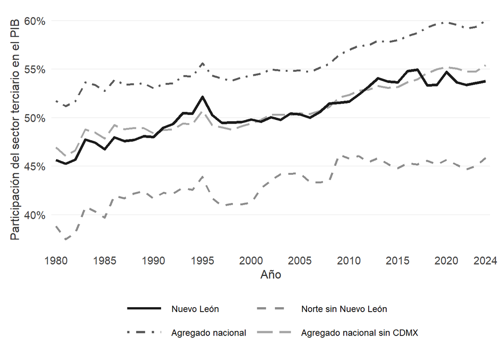

```r
# Colores en escala de grises
colores_comparacion_nl <- c(
  "Nuevo León" = "gray10",
  "Norte sin Nuevo León" = "gray55",
  "Agregado nacional" = "gray35",
  "Agregado nacional sin CDMX" = "gray65"
)

# Tipos de línea
lineas_comparacion_nl <- c(
  "Nuevo León" = "solid",
  "Norte sin Nuevo León" = "dashed",
  "Agregado nacional" = "dotdash",
  "Agregado nacional sin CDMX" = "longdash"
)

# Gráfica definitiva
grafica_trayectorias_nl <- ggplot(
  datos_trayectorias_nl,
  aes(
    x = año,
    y = participacion,
    color = referente,
    linetype = referente
  )
) +

  geom_line(
    linewidth = 1
  ) +

  # Destacar Nuevo León
  geom_line(
    data = datos_trayectorias_nl %>%
      filter(referente == "Nuevo León"),
    linewidth = 1.35,
    show.legend = FALSE
  ) +

  scale_color_manual(
    values = colores_comparacion_nl
  ) +

  scale_linetype_manual(
    values = lineas_comparacion_nl
  ) +

  scale_y_continuous(
    labels = percent_format(accuracy = 1),
    breaks = pretty_breaks(n = 6)
  ) +

  scale_x_continuous(
    breaks = c(
      seq(1980, 2020, 5),
      2024
    ),
    expand = expansion(mult = c(0.01, 0.01))
  ) +

  labs(
    x = "Año",
    y = "Participación del sector terciario en el PIB"
  ) +

  guides(
    color = guide_legend(
      nrow = 2,
      byrow = TRUE,
      override.aes = list(linewidth = 1.1)
    ),
    linetype = guide_legend(
      nrow = 2,
      byrow = TRUE
    )
  ) +

  tema_articulo +

  theme(
    legend.position = "bottom",
    legend.title = element_blank(),
    legend.text = element_text(
      size = 9,
      color = "black"
    ),
    legend.key.width = grid::unit(1.5, "cm"),
    plot.margin = margin(10, 10, 10, 10)
  )

# Mostrar gráfica
grafica_trayectorias_nl
```

```r
# Crear carpeta si todavía no existe
dir.create(
  "Figuras_Revista",
  showWarnings = FALSE,
  recursive = TRUE
)

# Exportar TIFF a 300 DPI
ggsave(
  filename = "Figuras_Revista/Figura_2_Comparacion_Nuevo_Leon.tiff",
  plot = grafica_trayectorias_nl,
  width = 16,
  height = 10,
  units = "cm",
  dpi = 300,
  compression = "lzw",
  bg = "white"
)
```

Entre 1980 y 2024, Nuevo León mantuvo una participación terciaria superior a la del resto de la región Norte. La entidad pasó de aproximadamente 45.5% a 53.8%, mientras que el Norte sin Nuevo León aumentó de cerca de 38.8% a 45.8%. Por tanto, la brecha favorable a Nuevo León se amplió de alrededor de 6.7 a 8 puntos porcentuales, lo que confirma una mayor presencia relativa del sector terciario dentro de su región.

## Tabla comparativa de niveles y cambios

```r
tabla_comparacion_nl <- base_comparacion_nl %>%
  filter(
    año %in% c(1980, 2024)
  ) %>%
  select(
    año,
    nuevo_leon,
    norte_sin_nl,
    agregado_nacional,
    agregado_nacional_sin_cdmx,
    promedio_estatal,
    mediana_estatal
  ) %>%
  pivot_longer(
    cols = -año,
    names_to = "referente",
    values_to = "participacion"
  ) %>%
  mutate(
    referente = dplyr::recode(
      referente,
      nuevo_leon = "Nuevo León",
      norte_sin_nl = "Norte sin Nuevo León",
      agregado_nacional = "Agregado nacional",
      agregado_nacional_sin_cdmx = "Agregado nacional sin CDMX",
      promedio_estatal = "Promedio de las entidades",
      mediana_estatal = "Mediana de las entidades"
    ),

    referente = factor(
      referente,
      levels = c(
        "Nuevo León",
        "Norte sin Nuevo León",
        "Agregado nacional",
        "Agregado nacional sin CDMX",
        "Promedio de las entidades",
        "Mediana de las entidades"
      )
    )
  ) %>%
  pivot_wider(
    names_from = año,
    values_from = participacion,
    names_prefix = "participacion_"
  ) %>%
  mutate(
    cambio_pp = (
      participacion_2024 -
        participacion_1980
    ) * 100
  ) %>%
  arrange(
    referente
  ) %>%
  transmute(
    Referente = referente,

    `Participación 1980 (%)` = round(
      participacion_1980 * 100,
      2
    ),

    `Participación 2024 (%)` = round(
      participacion_2024 * 100,
      2
    ),

    `Cambio 1980-2024 (p.p.)` = round(
      cambio_pp,
      2
    )
  )

tabla_comparacion_nl
```

```
## # A tibble: 6 × 4
##   Referente Participación 1980 (…¹ Participación 2024 (…² Cambio 1980-2024 (p.…³
##   <fct>                      <dbl>                  <dbl>                  <dbl>
## 1 Nuevo Le…                   45.6                   53.8                   8.13
## 2 Norte si…                   38.8                   45.9                   7.06
## 3 Agregado…                   51.7                   60.0                   8.25
## 4 Agregado…                   46.9                   55.4                   8.47
## 5 Promedio…                   51.6                   57.5                   5.9
## 6 Mediana …                   52.0                   56.4                   4.41
## # ℹ abbreviated names: ¹`Participación 1980 (%)`, ²`Participación 2024 (%)`,
## #   ³`Cambio 1980-2024 (p.p.)`
```

## Brechas de Nuevo León

La brecha se calcula como: Nuevo León - Referente

- una brecha positiva indica que Nuevo León está por encima;
- una brecha negativa indica que está por debajo;
- un movimiento hacia cero representa convergencia.

```r
# Preparar las brechas de Nuevo León frente a sus principales referentes

datos_brechas_nl <- base_comparacion_nl %>%
  transmute(
    año,
    `Norte sin Nuevo León` = brecha_norte_pp,
    `Agregado nacional` = brecha_nacional_pp,
    `Agregado nacional sin CDMX` = brecha_nacional_sin_cdmx_pp
  ) %>%
  pivot_longer(
    cols = -año,
    names_to = "referente",
    values_to = "brecha_pp"
  ) %>%
  mutate(
    referente = factor(
      referente,
      levels = c(
        "Norte sin Nuevo León",
        "Agregado nacional",
        "Agregado nacional sin CDMX"
      )
    )
  )
```

```r
# Definir los colores de las brechas

colores_brechas_nl <- c(
  "Norte sin Nuevo León" = "#4E79A7",
  "Agregado nacional" = "#8C564B",
  "Agregado nacional sin CDMX" = "#59A14F"
)
```

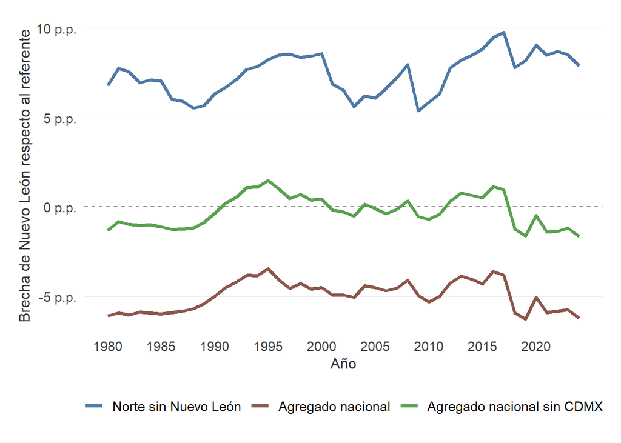

```r
# Graficar las brechas de Nuevo León frente a sus referentes

grafica_brechas_nl <- ggplot(
  datos_brechas_nl,
  aes(
    x = año,
    y = brecha_pp,
    color = referente
  )
) +

  geom_hline(
    yintercept = 0,
    color = "gray35",
    linewidth = 0.5,
    linetype = "dashed"
  ) +

  geom_line(
    linewidth = 1.25
  ) +

  scale_color_manual(
    values = colores_brechas_nl
  ) +

  scale_y_continuous(
    labels = label_number(
      accuracy = 1,
      suffix = " p.p."
    ),
    breaks = pretty_breaks(
      n = 6
    )
  ) +

  scale_x_continuous(
    breaks = seq(
      1980,
      2024,
      5
    )
  ) +

  labs(
    x = "Año",
    y = "Brecha de Nuevo León respecto al referente"
  ) +

  tema_articulo

grafica_brechas_nl
```

```r
guardar_grafica_png(
  grafica = grafica_brechas_nl,
  nombre_archivo = "grafica_brechas_nl",
  ancho = 9,
  alto = 6
)
```

## Resumen del cambio de las brechas

```r
# Resumir las brechas de Nuevo León en 1980 y 2024

tabla_brechas_nl <- datos_brechas_nl %>%
  filter(
    año %in% c(1980, 2024)
  ) %>%
  pivot_wider(
    names_from = año,
    values_from = brecha_pp,
    names_prefix = "brecha_"
  ) %>%
  mutate(
    variacion_brecha_pp = brecha_2024 -
      brecha_1980
  ) %>%
  transmute(
    Referente = referente,

    `Brecha en 1980 (p.p.)` = round(
      brecha_1980,
      2
    ),

    `Brecha en 2024 (p.p.)` = round(
      brecha_2024,
      2
    ),

    `Variación de la brecha (p.p.)` = round(
      variacion_brecha_pp,
      2
    )
  )

tabla_brechas_nl
```

```
## # A tibble: 3 × 4
##   Referente Brecha en 1980 (p.p.…¹ Brecha en 2024 (p.p.…² Variación de la brec…³
##   <fct>                      <dbl>                  <dbl>                  <dbl>
## 1 Norte si…                    6.8                   7.88                   1.07
## 2 Agregado…                   -6.1                  -6.22                  -0.12
## 3 Agregado…                   -1.3                  -1.65                  -0.34
## # ℹ abbreviated names: ¹`Brecha en 1980 (p.p.)`, ²`Brecha en 2024 (p.p.)`,
## #   ³`Variación de la brecha (p.p.)`
```

# Mapas de la terciarización

```r
# Descargar la cartografía y homologar los nombres con la base estatal

mapa_mexico_estados <- rnaturalearth::ne_download(
  scale = 10,
  type = "states",
  category = "cultural",
  returnclass = "sf"
) %>%
  filter(
    admin == "Mexico"
  ) %>%
  mutate(
    estado = case_when(
      name == "Distrito Federal" ~ "Ciudad de México",

      name %in% c(
        "Coahuila",
        "Coahuila de Zaragoza"
      ) ~ "Coahuila de Zaragoza",

      name %in% c(
        "Michoacán",
        "Michoacán de Ocampo"
      ) ~ "Michoacán de Ocampo",

      name %in% c(
        "Mexico",
        "México",
        "Estado de México"
      ) ~ "México",

      name %in% c(
        "Veracruz",
        "Veracruz de Ignacio de la Llave"
      ) ~ "Veracruz de Ignacio de la Llave",

      TRUE ~ name
    )
  ) %>%
  select(
    estado,
    geometry
  )
```

```
## Reading 'ne_10m_admin_1_states_provinces_lakes.zip' from naturalearth...
```

```r
# Crear el tema general para los mapas

tema_mapa <- theme_void(base_size = 13) +
  theme(
    legend.position = "right",

    legend.title = element_text(
      size = 10,
      color = "gray20"
    ),

    legend.text = element_text(
      size = 9,
      color = "gray25"
    ),

    plot.caption = element_text(
      size = 10,
      color = "gray35",
      hjust = 0
    ),

    plot.margin = margin(
      t = 10,
      r = 15,
      b = 10,
      l = 10
    )
  )
```

```r
# Definir una escala común para los mapas de participación terciaria

datos_terciarios_mapas <- base_estatal %>%
  filter(
    año %in% c(1980, 2024)
  )

# Definir los límites comunes con base en los datos observados

limites_terciario_mapas <- range(
  datos_terciarios_mapas$terciarias_pct,
  na.rm = TRUE
)

# Mostrar etiquetas cada 20 puntos porcentuales

quiebres_terciario_mapas <- seq(
  from = ceiling(
    limites_terciario_mapas[1] / 0.20
  ) * 0.20,

  to = floor(
    limites_terciario_mapas[2] / 0.20
  ) * 0.20,

  by = 0.20
)
```

## Mapa 1. Participación del sector terciario en el PIB estatal, 1980

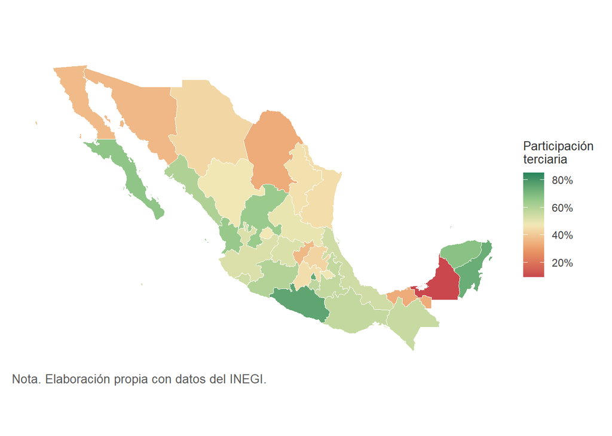

```r
# Integrar la participación terciaria de 1980 con la cartografía

mapa_terciario_1980_sf <- mapa_mexico_estados %>%
  left_join(
    base_estatal %>%
      filter(
        año == 1980
      ) %>%
      select(
        estado,
        terciarias_pct
      ),
    by = "estado"
  )

# Graficar la participación del sector terciario en 1980

grafica_mapa_terciario_1980 <- ggplot(
  mapa_terciario_1980_sf
) +

  geom_sf(
    aes(
      fill = terciarias_pct
    ),
    color = "white",
    linewidth = 0.3
  ) +

  scale_fill_gradientn(
    colors = c(
      "#C9474D",
      "#E99564",
      "#F2E8B6",
      "#91C788",
      "#26845B"
    ),
    limits = limites_terciario_mapas,
    breaks = quiebres_terciario_mapas,
    oob = scales::squish,
    labels = scales::label_percent(
      accuracy = 1
    ),
    name = "Participación\nterciaria"
  ) +

  coord_sf(
    datum = NA
  ) +

  labs(
    caption = "Nota. Elaboración propia con datos del INEGI."
  ) +

  tema_mapa

grafica_mapa_terciario_1980
```

```r
guardar_grafica_png(
  grafica = grafica_mapa_terciario_1980,
  nombre_archivo = "grafica_mapa_terciario_1980",
  ancho = 9,
  alto = 6
)
```

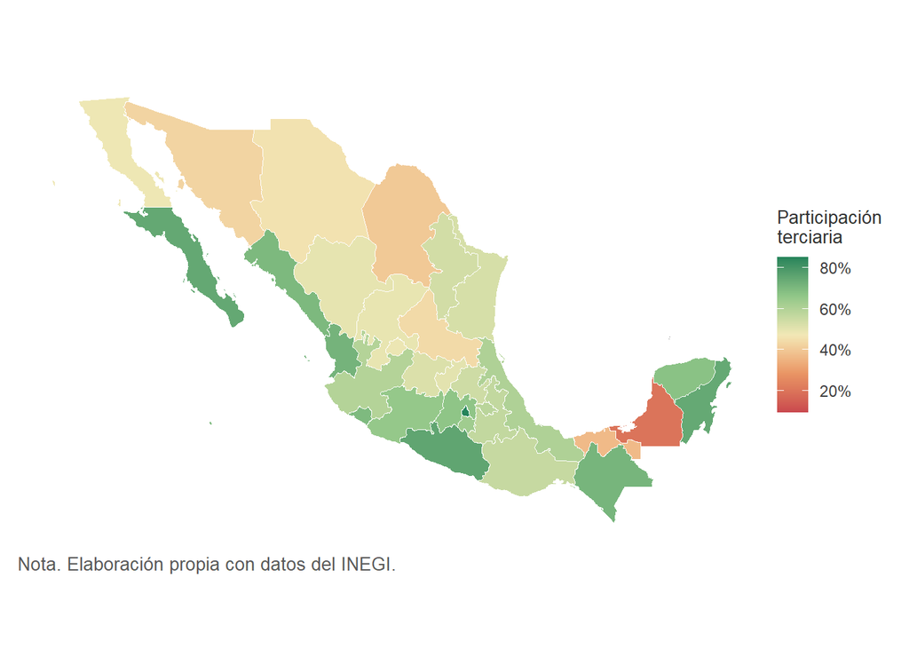

```r
# Integrar la participación terciaria de 2024 con la cartografía

mapa_terciario_2024_sf <- mapa_mexico_estados %>%
  left_join(
    base_estatal %>%
      filter(
        año == 2024
      ) %>%
      select(
        estado,
        terciarias_pct
      ),
    by = "estado"
  )

# Graficar la participación del sector terciario en 2024

grafica_mapa_terciario_2024 <- ggplot(
  mapa_terciario_2024_sf
) +

  geom_sf(
    aes(
      fill = terciarias_pct
    ),
    color = "white",
    linewidth = 0.3
  ) +

  scale_fill_gradientn(
    colors = c(
      "#C9474D",
      "#E99564",
      "#F2E8B6",
      "#91C788",
      "#26845B"
    ),
    limits = limites_terciario_mapas,
    breaks = quiebres_terciario_mapas,
    oob = scales::squish,
    labels = scales::label_percent(
      accuracy = 1
    ),
    name = "Participación\nterciaria"
  ) +

  coord_sf(
    datum = NA
  ) +

  labs(
    caption = "Nota. Elaboración propia con datos del INEGI."
  ) +

  tema_mapa

grafica_mapa_terciario_2024
```

```r
guardar_grafica_png(
  grafica = grafica_mapa_terciario_2024,
  nombre_archivo = "grafica_mapa_terciario_2024",
  ancho = 9,
  alto = 6
)
```

Entre 1980 y 2024 se observa un desplazamiento general hacia mayores niveles de participación terciaria, reflejado en la expansión de tonalidades verdes en gran parte del país. No obstante, persiste una marcada heterogeneidad territorial: los valores más altos se concentran en varias entidades del Pacífico, el centro-sur y Quintana Roo, mientras que Campeche y Tabasco permanecen entre los niveles más bajos.

Nuevo León se mantiene en un rango intermedio en ambos años, aunque con una mayor participación terciaria en 2024. La comparación confirma que la terciarización avanzó de forma desigual y que las diferencias no responden a una división regional uniforme, sino a la estructura productiva particular de cada entidad.

## Cambio estatal entre 1980 y 2024

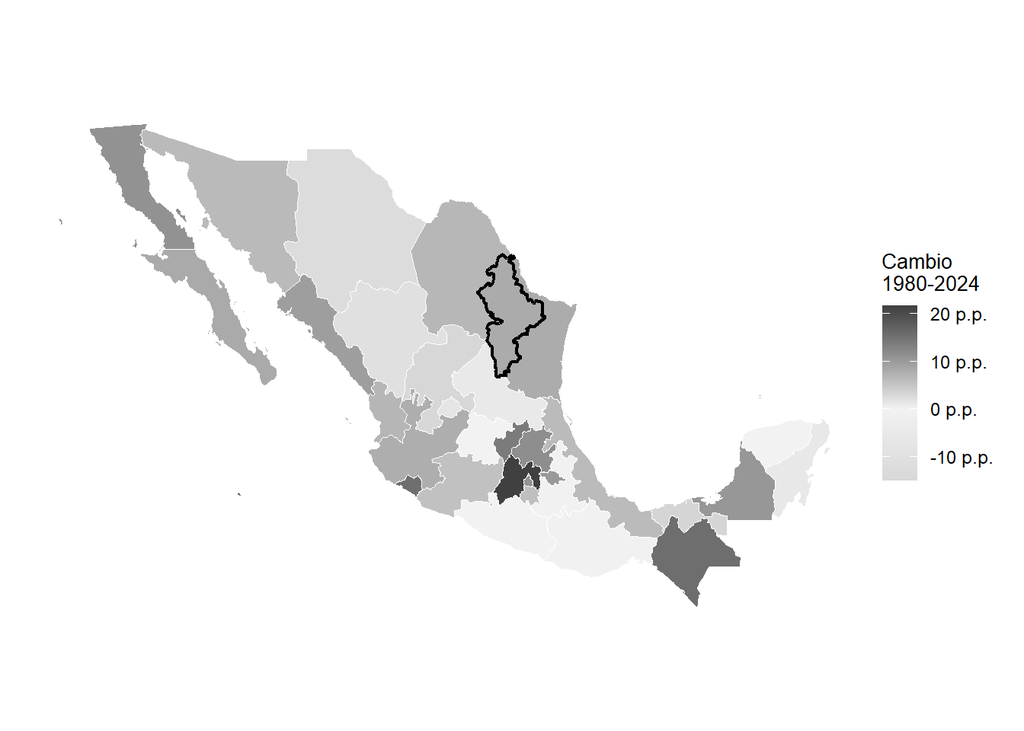

```r
# Integrar el cambio estatal con la cartografía

mapa_cambio_terciario_sf <- mapa_mexico_estados %>%
  left_join(
    cambio_estatal %>%
      select(
        estado,
        cambio_pp
      ),
    by = "estado"
  )

grafica_mapa_cambio_terciario <- ggplot(
  mapa_cambio_terciario_sf
) +

  geom_sf(
    aes(fill = cambio_pp),
    color = "white",
    linewidth = 0.3
  ) +

  # Destacar Nuevo León con contorno negro
  geom_sf(
    data = mapa_cambio_terciario_sf %>%
      filter(estado == "Nuevo León"),
    fill = NA,
    color = "black",
    linewidth = 0.8
  ) +

  scale_fill_gradient2(
    low = "gray80",
    mid = "gray95",
    high = "gray25",
    midpoint = 0,
    labels = label_number(
      accuracy = 1,
      suffix = " p.p."
    ),
    name = "Cambio\n1980-2024"
  ) +

  coord_sf(
    datum = NA
  ) +

  labs(
    caption = NULL
  ) +

  tema_mapa +

  theme(
    legend.position = "right",

    legend.title = element_text(
      size = 10,
      color = "black"
    ),

    legend.text = element_text(
      size = 9,
      color = "black"
    ),

    plot.margin = margin(10, 15, 10, 10)
  )

grafica_mapa_cambio_terciario
```

```r
# Exportar TIFF a 300 DPI
dir.create(
  "Figuras_Revista",
  showWarnings = FALSE,
  recursive = TRUE
)

ggsave(
  filename = "Figuras_Revista/Anexo_A_Mapa_cambio_terciario.tiff",
  plot = grafica_mapa_cambio_terciario,
  width = 16,
  height = 11,
  units = "cm",
  dpi = 300,
  compression = "lzw",
  bg = "white"
)
```

Entre 1980 y 2024 predominan los aumentos en la participación del sector terciario, aunque con diferencias importantes entre entidades. Los mayores avances se concentran en algunos estados del centro y sur, mientras que las disminuciones se localizan principalmente en parte del centro-norte y en casos aislados del sureste.

Nuevo León registra un cambio positivo de magnitud intermedia, por debajo de las entidades con los mayores incrementos, pero claramente alejado de aquellas que redujeron su participación terciaria. Los cambios se expresan en puntos porcentuales (p.p.), es decir, como la diferencia directa entre la participación de 1980 y la de 2024.

## Top 10 estados con mayor porcentaje terciario

```r
# Seleccionar las diez entidades con mayor participación terciaria en 2024

top10_terciario_2024 <- base_estatal %>%
  filter(
    año == 2024
  ) %>%
  arrange(
    desc(terciarias_pct)
  ) %>%
  slice_head(
    n = 10
  ) %>%
  mutate(
    posicion = row_number(),

    estado_grafica = paste0(
      posicion,
      ". ",
      estado
    ),

    estado_grafica = forcats::fct_reorder(
      estado_grafica,
      terciarias_pct
    ),

    grupo = if_else(
      estado == "Nuevo León",
      "Nuevo León",
      "Resto de las entidades"
    )
  )

# Preparar la tabla de las entidades con mayor participación terciaria

tabla_top10_terciario_2024 <- top10_terciario_2024 %>%
  transmute(
    Posición = posicion,
    Entidad = estado,

    `Participación terciaria (%)` = round(
      terciarias_pct * 100,
      2
    )
  )

tabla_top10_terciario_2024
```

```
## # A tibble: 10 × 3
##    Posición Entidad             `Participación terciaria (%)`
##       <int> <chr>                                       <dbl>
##  1        1 Ciudad de México                             85.3
##  2        2 Guerrero                                     75.8
##  3        3 Baja California Sur                          74.9
##  4        4 Quintana Roo                                 74.7
##  5        5 Nayarit                                      71.8
##  6        6 Chiapas                                      71.4
##  7        7 Sinaloa                                      70.2
##  8        8 Colima                                       70.0
##  9        9 Yucatán                                      67.6
## 10       10 México                                       66.8
```

# Relación entre participación inicial y cambio de la terciarización estatal

```r
# Construir la base estatal con la participación inicial y el cambio acumulado

relacion_terciarizacion_estatal <- base_estatal %>%
  filter(
    año %in% c(1980, 2024)
  ) %>%
  select(
    estado,
    año,
    terciarias_pct
  ) %>%
  tidyr::pivot_wider(
    names_from = año,
    values_from = terciarias_pct,
    names_prefix = "terciarias_"
  ) %>%
  mutate(
    participacion_inicial_pct = terciarias_1980 * 100,

    participacion_final_pct = terciarias_2024 * 100,

    cambio_terciario_pp = (
      terciarias_2024 -
        terciarias_1980
    ) * 100,

    grupo = if_else(
      estado == "Nuevo León",
      "Nuevo León",
      "Resto de las entidades"
    )
  )
```

```r
# Estimar la relación entre participación inicial y cambio terciario

modelo_relacion_terciarizacion <- lm(
  cambio_terciario_pp ~ participacion_inicial_pct,
  data = relacion_terciarizacion_estatal
)

summary(
  modelo_relacion_terciarizacion
)
```

```
##
## Call:
## lm(formula = cambio_terciario_pp ~ participacion_inicial_pct,
##     data = relacion_terciarizacion_estatal)
##
## Residuals:
##      Min       1Q   Median       3Q      Max
## -19.1034  -4.4787   0.7714   3.9977  14.8416
##
## Coefficients:
##                           Estimate Std. Error t value Pr(>|t|)
## (Intercept)               13.42121    4.57745   2.932  0.00639 **
## participacion_inicial_pct -0.14588    0.08574  -1.701  0.09923 .
## ---
## Signif. codes:  0 '***' 0.001 '**' 0.01 '*' 0.05 '.' 0.1 ' ' 1
##
## Residual standard error: 6.698 on 30 degrees of freedom
## Multiple R-squared:  0.08799,    Adjusted R-squared:  0.05759
## F-statistic: 2.894 on 1 and 30 DF,  p-value: 0.09923
```

En promedio, una participación terciaria inicial 1 punto porcentual mayor se asocia con un aumento posterior aproximadamente 0.146 puntos porcentuales menor. El signo negativo es compatible con convergencia relativa.

Los resultados muestran evidencia débil de convergencia relativa en la participación terciaria estatal. El coeficiente asociado con la participación inicial es negativo y estadísticamente significativo al 10%, lo que indica que las entidades con mayor participación terciaria en 1980 tendieron a registrar incrementos posteriores ligeramente menores. Sin embargo, la baja capacidad explicativa del modelo sugiere que el nivel inicial explica solo una parte reducida de las diferencias observadas entre entidades.

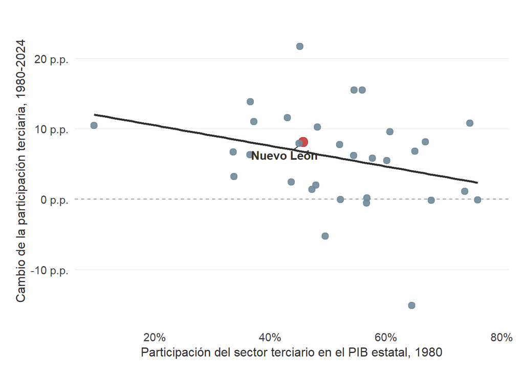

```r
# Graficar la relación entre participación inicial y cambio terciario

grafica_relacion_terciarizacion <- ggplot(
  relacion_terciarizacion_estatal,
  aes(
    x = participacion_inicial_pct,
    y = cambio_terciario_pp
  )
) +

  geom_hline(
    yintercept = 0,
    color = "gray60",
    linewidth = 0.5,
    linetype = "dashed"
  ) +

  geom_smooth(
    method = "lm",
    formula = y ~ x,
    se = FALSE,
    color = "#2F2F2F",
    linewidth = 0.9
  ) +

  geom_point(
    aes(
      color = grupo,
      size = grupo
    ),
    alpha = 0.9
  ) +

  ggrepel::geom_text_repel(
    data = relacion_terciarizacion_estatal %>%
      filter(
        estado == "Nuevo León"
      ),
    aes(
      label = estado
    ),
    color = "#2F2F2F",
    size = 4,
    fontface = "bold",
    box.padding = 0.5,
    point.padding = 0.4,
    min.segment.length = 0,
    show.legend = FALSE
  ) +

  scale_color_manual(
    values = c(
      "Nuevo León" = "#C43C39",
      "Resto de las entidades" = "#708A99"
    ),
    guide = "none"
  ) +

  scale_size_manual(
    values = c(
      "Nuevo León" = 4,
      "Resto de las entidades" = 2.7
    ),
    guide = "none"
  ) +

  scale_x_continuous(
    labels = scales::label_number(
      accuracy = 1,
      suffix = "%"
    ),
    expand = expansion(
      mult = c(
        0.05,
        0.08
      )
    )
  ) +

  scale_y_continuous(
    labels = scales::label_number(
      accuracy = 1,
      suffix = " p.p."
    ),
    expand = expansion(
      mult = c(
        0.08,
        0.12
      )
    )
  ) +

  labs(
    x = "Participación del sector terciario en el PIB estatal, 1980",
    y = "Cambio de la participación terciaria, 1980-2024"
  ) +

  tema_articulo +

  theme(
    legend.position = "none"
  )

grafica_relacion_terciarizacion
```

```r
guardar_grafica_png(
  grafica = grafica_relacion_terciarizacion,
  nombre_archivo = "grafica_relacion_terciarizacion",
  ancho = 9,
  alto = 6
)
```

# Participación de Nuevo León en el PIB terciario nacional

```r
nacional <- read_excel(archivo_base, sheet = "Nacional")
```

```r
# Seleccionar el PIB terciario de Nuevo León

terciario_nuevo_leon <- base_estatal %>%
  filter(
    estado == "Nuevo León"
  ) %>%
  select(
    año,
    terciarias_nivel
  ) %>%
  rename(
    pib_terciario_nuevo_leon = terciarias_nivel
  )

# Seleccionar el PIB terciario nacional

terciario_nacional <- nacional %>%
  filter(
    estado == "Nacional"
  ) %>%
  select(
    año,
    terciarias_nivel
  ) %>%
  rename(
    pib_terciario_nacional = terciarias_nivel
  )
```

```r
# Calcular la participación de Nuevo León en el PIB terciario nacional

participacion_nl_terciario_nacional <- terciario_nuevo_leon %>%
  inner_join(
    terciario_nacional,
    by = "año"
  ) %>%
  mutate(
    participacion_nl_terciario_nacional =
      pib_terciario_nuevo_leon /
      pib_terciario_nacional
  ) %>%
  arrange(
    año
  )
```

```r
# Resumir la participación de Nuevo León en 1980 y 2024

tabla_participacion_nl_terciario <- participacion_nl_terciario_nacional %>%
  filter(
    año %in% c(1980, 2024)
  ) %>%
  transmute(
    año,

    participacion_pct =
      participacion_nl_terciario_nacional * 100
  ) %>%
  tidyr::pivot_wider(
    names_from = año,
    values_from = participacion_pct,
    names_prefix = "participacion_"
  ) %>%
  transmute(
    `Participación en 1980 (%)` = round(
      participacion_1980,
      2
    ),

    `Participación en 2024 (%)` = round(
      participacion_2024,
      2
    ),

    `Cambio 1980-2024 (p.p.)` = round(
      participacion_2024 -
        participacion_1980,
      2
    )
  )

tabla_participacion_nl_terciario
```

```
## # A tibble: 1 × 3
##   `Participación en 1980 (%)` `Participación en 2024 (%)` Cambio 1980-2024 (p.…¹
##                         <dbl>                       <dbl>                  <dbl>
## 1                        5.18                        7.27                   2.09
## # ℹ abbreviated name: ¹`Cambio 1980-2024 (p.p.)`
```

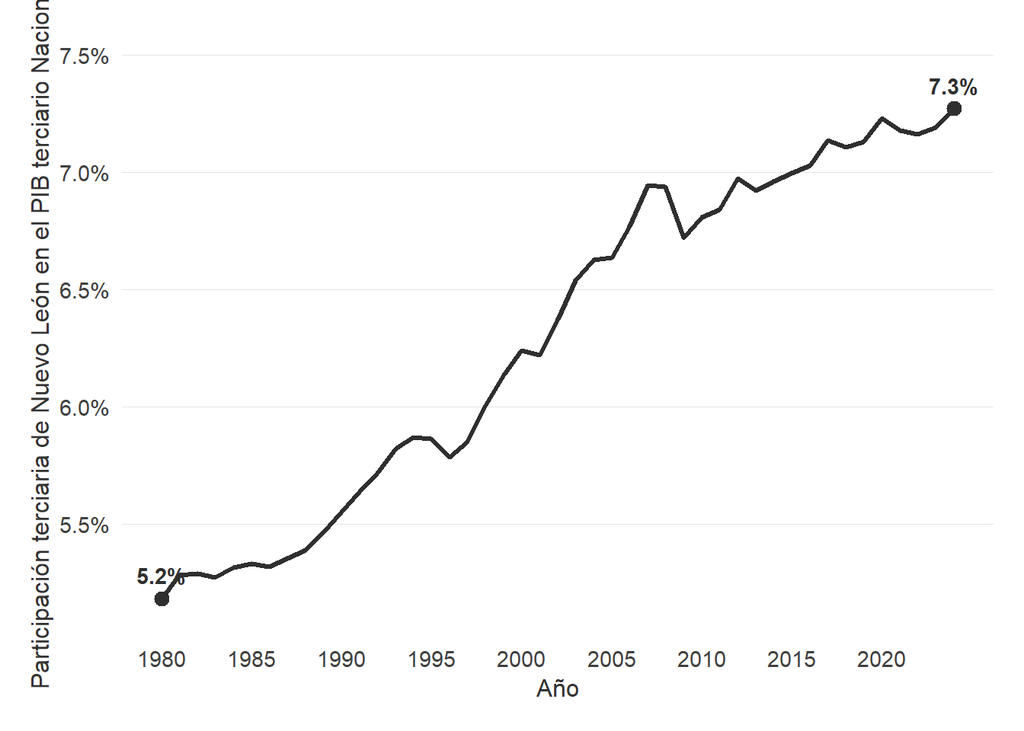

```r
# Preparar las etiquetas de los años inicial y final

etiquetas_participacion_nl_terciario <- participacion_nl_terciario_nacional %>%
  filter(
    año %in% c(1980, 2024)
  ) %>%
  mutate(
    etiqueta = scales::percent(
      participacion_nl_terciario_nacional,
      accuracy = 0.1
    )
  )

# Graficar la participación de Nuevo León en el terciario nacional

grafica_participacion_nl_terciario <- ggplot(
  participacion_nl_terciario_nacional,
  aes(
    x = año,
    y = participacion_nl_terciario_nacional
  )
) +

  geom_line(
    color = "#2F2F2F",
    linewidth = 1.2
  ) +

  geom_point(
    data = etiquetas_participacion_nl_terciario,
    color = "#2F2F2F",
    size = 3
  ) +

  geom_text(
    data = etiquetas_participacion_nl_terciario,
    aes(
      label = etiqueta
    ),
    color = "#2F2F2F",
    fontface = "bold",
    size = 3.8,
    vjust = -0.9
  ) +

  scale_x_continuous(
    breaks = seq(
      1980,
      2024,
      by = 5
    )
  ) +

  scale_y_continuous(
    labels = scales::label_percent(
      accuracy = 0.1
    ),
    expand = expansion(
      mult = c(
        0.08,
        0.16
      )
    )
  ) +

  labs(
    x = "Año",
    y = "Participación terciaria de Nuevo León en el PIB terciario Nacional"
  ) +

  tema_articulo +

  theme(
    panel.grid.minor = element_blank()
  )

grafica_participacion_nl_terciario
```

```r
guardar_grafica_png(
  grafica = grafica_participacion_nl_terciario,
  nombre_archivo = "grafica_participacion_nl_terciario",
  ancho = 9,
  alto = 6
)
```

La participación de Nuevo León en el sector terciario nacional aumentó de 5.18% en 1980 a 7.27% en 2024, un incremento de 2.09 puntos porcentuales. El avance fue especialmente marcado desde finales de la década de 1980 hasta mediados de los 2000, seguido de fluctuaciones moderadas y una tendencia ascendente en los años recientes.

En conjunto, la trayectoria indica que Nuevo León ganó peso relativo dentro de la actividad terciaria del país y alcanzó en 2024 su nivel más alto del periodo.

## Comparativa con otros estados

```r
# Seleccionar el PIB terciario nacional de 2024

terciario_nacional_2024 <- nacional %>%
  filter(
    estado == "Nacional",
    año == 2024
  ) %>%
  transmute(
    año,
    terciario_nacional = terciarias_nivel
  )
```

```r
# Calcular la aportación de cada entidad al PIB terciario nacional

ranking_terciario_nacional_2024 <- base_estatal %>%
  filter(
    año == 2024
  ) %>%
  select(
    estado,
    año,
    terciarias_nivel
  ) %>%
  left_join(
    terciario_nacional_2024,
    by = "año"
  ) %>%
  mutate(
    participacion_terciario_nacional =
      terciarias_nivel /
      terciario_nacional
  ) %>%
  arrange(
    desc(participacion_terciario_nacional)
  ) %>%
  mutate(
    posicion = row_number(),

    grupo = if_else(
      estado == "Nuevo León",
      "Nuevo León",
      "Resto de las entidades"
    )
  )
```

```r
# Consultar la posición de Nuevo León

posicion_nuevo_leon_terciario <- ranking_terciario_nacional_2024 %>%
  filter(
    estado == "Nuevo León"
  ) %>%
  transmute(
    Entidad = estado,
    Posición = posicion,

    `Participación en el terciario nacional (%)` = round(
      participacion_terciario_nacional * 100,
      2
    )
  )

posicion_nuevo_leon_terciario
```

```
## # A tibble: 1 × 3
##   Entidad    Posición `Participación en el terciario nacional (%)`
##   <chr>         <int>                                        <dbl>
## 1 Nuevo León        4                                         7.27
```

```r
# Seleccionar las diez entidades con mayor aportación terciaria

top10_terciario_nacional_2024 <- ranking_terciario_nacional_2024 %>%
  slice_head(
    n = 10
  ) %>%
  mutate(
    estado_grafica = paste0(
      posicion,
      ". ",
      estado
    ),

    estado_grafica = forcats::fct_reorder(
      estado_grafica,
      participacion_terciario_nacional
    )
  )

# Preparar la tabla del Top 10

tabla_top10_terciario_nacional_2024 <-
  top10_terciario_nacional_2024 %>%
  transmute(
    Posición = posicion,
    Entidad = estado,

    `Participación nacional (%)` = round(
      participacion_terciario_nacional * 100,
      2
    )
  )

tabla_top10_terciario_nacional_2024
```

```
## # A tibble: 10 × 3
##    Posición Entidad                         `Participación nacional (%)`
##       <int> <chr>                                                  <dbl>
##  1        1 Ciudad de México                                       21.8
##  2        2 México                                                 10.2
##  3        3 Jalisco                                                 7.32
##  4        4 Nuevo León                                              7.27
##  5        5 Veracruz de Ignacio de la Llave                         4.37
##  6        6 Guanajuato                                              4.01
##  7        7 Puebla                                                  3.31
##  8        8 Baja California                                         3.01
##  9        9 Michoacán de Ocampo                                     2.94
## 10       10 Chihuahua                                               2.82
```

# Progreso de las actividades secundarias y terciarias en las entidades federativas

```r
# Construir la base estatal de comparación secundaria y terciaria

base_progreso_sectorial <- base_estatal %>%
  filter(
    año %in% c(1980, 2024)
  ) %>%
  select(
    estado,
    año,
    secundarias_nivel,
    terciarias_nivel,
    secundarias_pct,
    terciarias_pct
  ) %>%
  tidyr::pivot_wider(
    names_from = año,
    values_from = c(
      secundarias_nivel,
      terciarias_nivel,
      secundarias_pct,
      terciarias_pct
    ),
    names_sep = "_"
  ) %>%
  mutate(
    cambio_secundario_pp = (
      secundarias_pct_2024 -
        secundarias_pct_1980
    ) * 100,

    cambio_terciario_pp = (
      terciarias_pct_2024 -
        terciarias_pct_1980
    ) * 100,

    crecimiento_secundario_anual_pct = if_else(
      secundarias_nivel_1980 > 0 &
        secundarias_nivel_2024 > 0,

      (
        (
          secundarias_nivel_2024 /
            secundarias_nivel_1980
        ) ^ (
          1 / (2024 - 1980)
        ) - 1
      ) * 100,

      NA_real_
    ),

    crecimiento_terciario_anual_pct = if_else(
      terciarias_nivel_1980 > 0 &
        terciarias_nivel_2024 > 0,

      (
        (
          terciarias_nivel_2024 /
            terciarias_nivel_1980
        ) ^ (
          1 / (2024 - 1980)
        ) - 1
      ) * 100,

      NA_real_
    )
  )
```

## Reorientación terciaria

```r
# Calcular la reorientación estructural y la diferencia de crecimiento

base_progreso_sectorial <- base_progreso_sectorial %>%
  mutate(
    reorientacion_terciaria_pp =
      cambio_terciario_pp -
      cambio_secundario_pp,

    diferencia_crecimiento_pct =
      crecimiento_terciario_anual_pct -
      crecimiento_secundario_anual_pct,

    patron_estructural = case_when(
      cambio_terciario_pp > 0 &
        cambio_secundario_pp < 0 ~
        "Aumentó terciario y disminuyó secundario",

      cambio_terciario_pp > 0 &
        cambio_secundario_pp >= 0 ~
        "Aumentaron ambos sectores",

      cambio_terciario_pp <= 0 &
        cambio_secundario_pp > 0 ~
        "Aumentó secundario y disminuyó terciario",

      TRUE ~
        "Disminuyeron ambos sectores"
    ),

    grupo = if_else(
      estado == "Nuevo León",
      "Nuevo León",
      "Resto de las entidades"
    )
  )
```

## Comparación de Nuevo León con las entidades federativas

```r
# Calcular la posición relativa de cada entidad

base_progreso_sectorial <- base_progreso_sectorial %>%
  mutate(
    percentil_cambio_secundario =
      percent_rank(
        cambio_secundario_pp
      ) * 100,

    percentil_cambio_terciario =
      percent_rank(
        cambio_terciario_pp
      ) * 100,

    percentil_reorientacion =
      percent_rank(
        reorientacion_terciaria_pp
      ) * 100,

    percentil_crecimiento_secundario =
      percent_rank(
        crecimiento_secundario_anual_pct
      ) * 100,

    percentil_crecimiento_terciario =
      percent_rank(
        crecimiento_terciario_anual_pct
      ) * 100
  )

# Calcular la posición de cada entidad en los indicadores sectoriales

base_progreso_sectorial <- base_progreso_sectorial %>%
  mutate(
    posicion_cambio_secundario = min_rank(
      desc(cambio_secundario_pp)
    ),

    posicion_cambio_terciario = min_rank(
      desc(cambio_terciario_pp)
    ),

    posicion_reorientacion = min_rank(
      desc(reorientacion_terciaria_pp)
    ),

    posicion_crecimiento_secundario = min_rank(
      desc(crecimiento_secundario_anual_pct)
    ),

    posicion_crecimiento_terciario = min_rank(
      desc(crecimiento_terciario_anual_pct)
    ),

    posicion_diferencia_crecimiento = min_rank(
      desc(diferencia_crecimiento_pct)
    )
  )
```

```r
# Resumir los resultados y posiciones de Nuevo León

tabla_nuevo_leon_progreso_sectorial <- base_progreso_sectorial %>%
  filter(
    estado == "Nuevo León"
  ) %>%
  transmute(
    Entidad = estado,

    `Cambio secundario (p.p.)` = round(
      cambio_secundario_pp,
      2
    ),

    `Posición en cambio secundario` = paste0(
      posicion_cambio_secundario,
      " de 32"
    ),

    `Cambio terciario (p.p.)` = round(
      cambio_terciario_pp,
      2
    ),

    `Posición en cambio terciario` = paste0(
      posicion_cambio_terciario,
      " de 32"
    ),

    `Reorientación terciaria (p.p.)` = round(
      reorientacion_terciaria_pp,
      2
    ),

    `Posición en reorientación` = paste0(
      posicion_reorientacion,
      " de 32"
    ),

    `Crecimiento secundario anual (%)` = round(
      crecimiento_secundario_anual_pct,
      2
    ),

    `Posición en crecimiento secundario` = paste0(
      posicion_crecimiento_secundario,
      " de 32"
    ),

    `Crecimiento terciario anual (%)` = round(
      crecimiento_terciario_anual_pct,
      2
    ),

    `Posición en crecimiento terciario` = paste0(
      posicion_crecimiento_terciario,
      " de 32"
    ),

    `Diferencia de crecimiento (p.p.)` = round(
      diferencia_crecimiento_pct,
      2
    ),

    `Posición en diferencia de crecimiento` = paste0(
      posicion_diferencia_crecimiento,
      " de 32"
    ),

    `Patrón estructural` = patron_estructural
  )

tabla_nuevo_leon_progreso_sectorial
```

```
## # A tibble: 1 × 14
##   Entidad   Cambio secundario (p…¹ Posición en cambio s…² Cambio terciario (p.…³
##   <chr>                      <dbl> <chr>                                   <dbl>
## 1 Nuevo Le…                  -6.92 20 de 32                                 8.13
## # ℹ abbreviated names: ¹`Cambio secundario (p.p.)`,
## #   ²`Posición en cambio secundario`, ³`Cambio terciario (p.p.)`
## # ℹ 10 more variables: `Posición en cambio terciario` <chr>,
## #   `Reorientación terciaria (p.p.)` <dbl>, `Posición en reorientación` <chr>,
## #   `Crecimiento secundario anual (%)` <dbl>,
## #   `Posición en crecimiento secundario` <chr>,
## #   `Crecimiento terciario anual (%)` <dbl>, …
```

Entre 1980 y 2024, la participación secundaria de Nuevo León disminuyó 6.92 puntos porcentuales (p.p.), mientras que la terciaria aumentó 8.13 p.p. Esta combinación produjo una reorientación terciaria de 15.05 p.p., definida como la diferencia entre el aumento terciario y el cambio secundario. La entidad ocupó las posiciones 20, 12 y 13 de 32 en cambio secundario, cambio terciario y reorientación, respectivamente.

## Comparar con la distribución estatal

```r
# Comparar Nuevo León con el promedio y la mediana estatal

tabla_comparacion_progreso_sectorial <- bind_rows(
  base_progreso_sectorial %>%
    filter(
      estado == "Nuevo León"
    ) %>%
    transmute(
      Referencia = "Nuevo León",

      `Cambio secundario (p.p.)` = cambio_secundario_pp,

      `Cambio terciario (p.p.)` = cambio_terciario_pp,

      `Reorientación terciaria (p.p.)` =
        reorientacion_terciaria_pp,

      `Crecimiento secundario anual (%)` =
        crecimiento_secundario_anual_pct,

      `Crecimiento terciario anual (%)` =
        crecimiento_terciario_anual_pct
    ),

  base_progreso_sectorial %>%
    summarise(
      Referencia = "Promedio estatal",

      `Cambio secundario (p.p.)` = mean(
        cambio_secundario_pp,
        na.rm = TRUE
      ),

      `Cambio terciario (p.p.)` = mean(
        cambio_terciario_pp,
        na.rm = TRUE
      ),

      `Reorientación terciaria (p.p.)` = mean(
        reorientacion_terciaria_pp,
        na.rm = TRUE
      ),

      `Crecimiento secundario anual (%)` = mean(
        crecimiento_secundario_anual_pct,
        na.rm = TRUE
      ),

      `Crecimiento terciario anual (%)` = mean(
        crecimiento_terciario_anual_pct,
        na.rm = TRUE
      )
    ),

  base_progreso_sectorial %>%
    summarise(
      Referencia = "Mediana estatal",

      `Cambio secundario (p.p.)` = median(
        cambio_secundario_pp,
        na.rm = TRUE
      ),

      `Cambio terciario (p.p.)` = median(
        cambio_terciario_pp,
        na.rm = TRUE
      ),

      `Reorientación terciaria (p.p.)` = median(
        reorientacion_terciaria_pp,
        na.rm = TRUE
      ),

      `Crecimiento secundario anual (%)` = median(
        crecimiento_secundario_anual_pct,
        na.rm = TRUE
      ),

      `Crecimiento terciario anual (%)` = median(
        crecimiento_terciario_anual_pct,
        na.rm = TRUE
      )
    )
) %>%
  mutate(
    across(
      where(is.numeric),
      ~ round(
        .x,
        2
      )
    )
  )

tabla_comparacion_progreso_sectorial
```

```
## # A tibble: 3 × 6
##   Referencia       `Cambio secundario (p.p.)` `Cambio terciario (p.p.)`
##   <chr>                                 <dbl>                     <dbl>
## 1 Nuevo León                            -6.92                      8.13
## 2 Promedio estatal                      -4.59                      5.9
## 3 Mediana estatal                       -5.72                      6.49
## # ℹ 3 more variables: `Reorientación terciaria (p.p.)` <dbl>,
## #   `Crecimiento secundario anual (%)` <dbl>,
## #   `Crecimiento terciario anual (%)` <dbl>
```

La disminución secundaria de Nuevo León fue mayor que el promedio (-4.59 p.p.) y la mediana estatal (-5.72 p.p.), mientras que su aumento terciario superó ambos referentes, de 5.90 y 6.49 p.p. En consecuencia, su reorientación terciaria también fue superior al promedio (10.49 p.p.) y a la mediana (13.06 p.p.), lo que ubica a la entidad dentro de la mitad superior de la distribución nacional.

## Cambios en las participaciones secundaria y terciaria

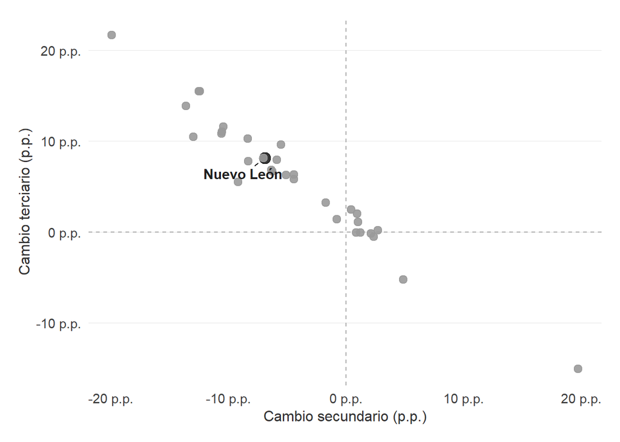

```r
# Graficar los cambios de las participaciones sectoriales

grafica_cambio_sectorial <- ggplot(
  base_progreso_sectorial,
  aes(
    x = cambio_secundario_pp,
    y = cambio_terciario_pp
  )
) +

  geom_vline(
    xintercept = 0,
    color = "gray65",
    linewidth = 0.5,
    linetype = "dashed"
  ) +

  geom_hline(
    yintercept = 0,
    color = "gray65",
    linewidth = 0.5,
    linetype = "dashed"
  ) +

  geom_point(
    aes(
      color = grupo,
      size = grupo
    ),
    alpha = 0.9
  ) +

  ggrepel::geom_text_repel(
    data = base_progreso_sectorial %>%
      filter(
        estado == "Nuevo León"
      ),
    aes(
      label = estado
    ),
    color = "#1F1F1F",
    size = 4,
    fontface = "bold",
    box.padding = 0.5,
    point.padding = 0.4,
    min.segment.length = 0,
    show.legend = FALSE
  ) +

  scale_color_manual(
    values = c(
      "Nuevo León" = "#1F1F1F",
      "Resto de las entidades" = "#9A9A9A"
    ),
    guide = "none"
  ) +

  scale_size_manual(
    values = c(
      "Nuevo León" = 4,
      "Resto de las entidades" = 2.7
    ),
    guide = "none"
  ) +

  scale_x_continuous(
    labels = scales::label_number(
      accuracy = 1,
      suffix = " p.p."
    )
  ) +

  scale_y_continuous(
    labels = scales::label_number(
      accuracy = 1,
      suffix = " p.p."
    )
  ) +

  labs(
    x = "Cambio secundario (p.p.)",
    y = "Cambio terciario (p.p.)"
  ) +

  tema_articulo +

  theme(
    legend.position = "none",
    panel.grid.minor = element_blank()
  )

grafica_cambio_sectorial
```

```r
guardar_grafica_png(
  grafica = grafica_cambio_sectorial,
  nombre_archivo = "grafica_cambio_sectorial",
  ancho = 9,
  alto = 6
)
```

La gráfica muestra una relación inversa entre los cambios en la participación de los sectores secundario y terciario de las entidades federativas: en general, los estados que redujeron su participación secundaria registraron aumentos en la terciaria. La mayoría se concentra en el cuadrante superior izquierdo, lo que sugiere un desplazamiento relativo de la estructura económica hacia las actividades terciarias.

Nuevo León sigue este patrón, con una disminución cercana a 7 puntos porcentuales en el sector secundario y un aumento aproximado de 8 puntos en el terciario. Esta correlación describe una asociación entre ambos cambios, pero no implica por sí misma una relación causal ni una sustitución directa entre sectores.

## Reorientación relativa hacia las actividades terciarias

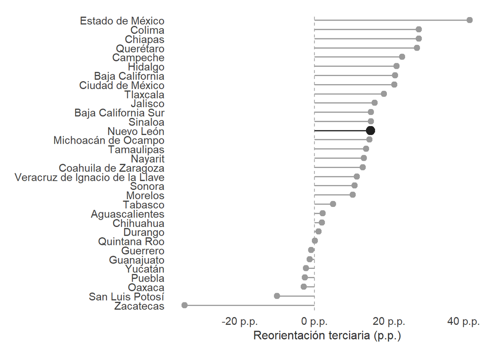

```r
# Ordenar las entidades por reorientación terciaria

grafica_reorientacion_base <- base_progreso_sectorial %>%
  mutate(
    estado = forcats::fct_reorder(
      estado,
      reorientacion_terciaria_pp
    )
  )

# Graficar la reorientación terciaria de las entidades

grafica_reorientacion_terciaria <- ggplot(
  grafica_reorientacion_base,
  aes(
    x = reorientacion_terciaria_pp,
    y = estado
  )
) +

  geom_vline(
    xintercept = 0,
    color = "gray65",
    linewidth = 0.5,
    linetype = "dashed"
  ) +

  geom_segment(
    aes(
      x = 0,
      xend = reorientacion_terciaria_pp,
      yend = estado,
      color = grupo
    ),
    linewidth = 0.7
  ) +

  geom_point(
    aes(
      color = grupo,
      size = grupo
    )
  ) +

  scale_y_discrete(
    labels = c(
      "México" = "Estado de México"
    )
  ) +

  scale_color_manual(
    values = c(
      "Nuevo León" = "#1F1F1F",
      "Resto de las entidades" = "#9A9A9A"
    ),
    guide = "none"
  ) +

  scale_size_manual(
    values = c(
      "Nuevo León" = 3.8,
      "Resto de las entidades" = 2.4
    ),
    guide = "none"
  ) +

  scale_x_continuous(
    labels = scales::label_number(
      accuracy = 1,
      suffix = " p.p."
    )
  ) +

  labs(
    x = "Reorientación terciaria (p.p.)",
    y = NULL
  ) +

  tema_articulo +

  theme(
    legend.position = "none",
    panel.grid.major.y = element_blank(),
    panel.grid.minor = element_blank()
  )

grafica_reorientacion_terciaria
```

```r
guardar_grafica_png(
  grafica = grafica_reorientacion_terciaria,
  nombre_archivo = "grafica_reorientacion_terciaria",
  ancho = 9,
  alto = 6
)
```

La mayoría de las entidades que redujeron la participación secundaria aumentaron la terciaria. Nuevo León se localiza en este grupo, aunque sin encontrarse entre los casos de reorientación más pronunciada. El patrón describe un cambio en la composición sectorial, pero no implica que el crecimiento absoluto de la industria haya sido negativo.

## Crecimiento de los sectores secundario y terciario

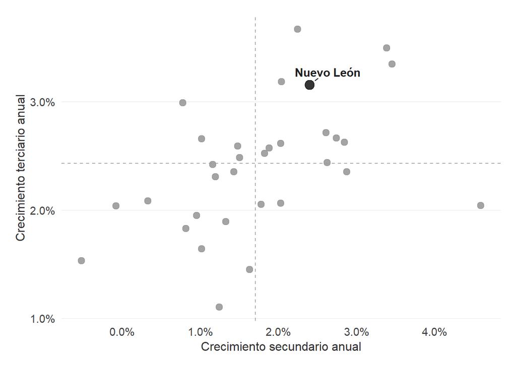

```r
# Calcular las medianas estatales de crecimiento sectorial

mediana_crecimiento_secundario <- median(
  base_progreso_sectorial$crecimiento_secundario_anual_pct,
  na.rm = TRUE
)

mediana_crecimiento_terciario <- median(
  base_progreso_sectorial$crecimiento_terciario_anual_pct,
  na.rm = TRUE
)

# Graficar el crecimiento anual secundario y terciario

grafica_crecimiento_sectorial <- ggplot(
  base_progreso_sectorial,
  aes(
    x = crecimiento_secundario_anual_pct,
    y = crecimiento_terciario_anual_pct
  )
) +

  geom_vline(
    xintercept = mediana_crecimiento_secundario,
    color = "gray65",
    linewidth = 0.5,
    linetype = "dashed"
  ) +

  geom_hline(
    yintercept = mediana_crecimiento_terciario,
    color = "gray65",
    linewidth = 0.5,
    linetype = "dashed"
  ) +

  geom_point(
    aes(
      color = grupo,
      size = grupo
    ),
    alpha = 0.9
  ) +

  ggrepel::geom_text_repel(
    data = base_progreso_sectorial %>%
      filter(
        estado == "Nuevo León"
      ),
    aes(
      label = estado
    ),
    color = "#1F1F1F",
    size = 4,
    fontface = "bold",
    box.padding = 0.5,
    point.padding = 0.4,
    min.segment.length = 0,
    show.legend = FALSE
  ) +

  scale_color_manual(
    values = c(
      "Nuevo León" = "#1F1F1F",
      "Resto de las entidades" = "#9A9A9A"
    ),
    guide = "none"
  ) +

  scale_size_manual(
    values = c(
      "Nuevo León" = 4,
      "Resto de las entidades" = 2.7
    ),
    guide = "none"
  ) +

  scale_x_continuous(
    labels = scales::label_number(
      accuracy = 0.1,
      suffix = "%"
    )
  ) +

  scale_y_continuous(
    labels = scales::label_number(
      accuracy = 0.1,
      suffix = "%"
    )
  ) +

  labs(
    x = "Crecimiento secundario anual",
    y = "Crecimiento terciario anual"
  ) +

  tema_articulo +

  theme(
    legend.position = "none",
    panel.grid.minor = element_blank()
  )

grafica_crecimiento_sectorial
```

El sector secundario de Nuevo León creció a una tasa anual de 2.40%, superior al promedio y la mediana estatales, y ocupó la posición 9 de 32. El sector terciario creció 3.16% anual, ubicándose en la posición 5; por tanto, superó al secundario en 0.76 p.p. anuales. La entidad combina así un crecimiento elevado de ambos sectores con un mayor dinamismo relativo de las actividades terciarias.